# Введение в МСА. Множественная регрессия. Гетероскедастичность

### Дата занятия: 24 марта

```r
library(haven)
library(ggplot2)
library(sandwich)
library(lmtest)
library(skedastic)
```

## 1. Данные

Источником данных является исследование авторов Kalenborn C., Lessman C. “The impact of democracy and press freedom on corruption: Conditionality matters”. Эта статья доступна по [ссылке](https://yadi.sk/i/nlEQUoWKiqY0UA).

Ниже представлено краткое описание данных:

**VARIABLES**

- cpi - Corruption Perception Index. The scale ranges from 0 to 10, where 10 stands for the highest level of corruption
- dem - Vanhanen’s democratization index. The scale ranges from 0 to 100, where 100 stands for the highest level of democracy
- fp - freedom of press: Freedom House. The scale ranges from 0 to 100, where 100 stands for the highest level of freedom of press
- loggdppc - natural logarithm of GDP per capita: World Bank.
- stab - political stability. The index is constructed on the basis of “Political Stability” and “Absence of Violence/Terrorism” indicators from the Worldwide Governance Indicators. The scale ranges from -2.5 to 2.5, where 2.5 stands for the highest level of political stability
- britcol - a dummy variable, 1 - former British colony, 0 - otherwise.

Давайте откроем массив данных.

```r
lab2 <- read_dta("reg_lab2.dta")
lab2 <- na.omit(lab2)
head(lab2)
```

| country | loggdppc | britcol | dem | stab | fp | cpi |
| --- | --- | --- | --- | --- | --- | --- |
| Afghanistan | 6.216606 | 0 | 10.766666 | -2.495173931 | 27.66667 | 7.733000 |
| Albania | 8.216088 | 0 | 24.666666 | -0.243981183 | 50.00000 | 6.449667 |
| Algeria | 8.427268 | 0 | 10.100000 | -1.127763748 | 37.83333 | 6.466333 |
| Angola | 8.371011 | 0 | 2.383333 | -0.505494356 | 37.16667 | 7.416333 |
| Argentina | 9.118225 | 0 | 28.466665 | 0.007387357 | 51.66667 | 6.549666 |
| Armenia | 8.016318 | 0 | 22.616667 | -0.009873525 | 34.50000 | 6.599667 |

## 2. Модель множественной регрессии и графики взаимосвязи коррупции и ключевых предикторов

Оценим множественную регрессионную модель – одну из тех, которую оценивали авторы исследования. Коррупция использовалась в роли зависимой переменной, ключевыми предикторами были уровень демократии и свобода прессы. Критически выбор этих переменных (в том числе, и контролей) мы уже обсуждали на прошлом занятии.

```r
m1 <- lm(cpi ~ dem + fp + loggdppc + stab + britcol, data = lab2)
summary(m1)
```

```
##
## Call:
## lm(formula = cpi ~ dem + fp + loggdppc + stab + britcol, data = lab2)
##
## Residuals:
##     Min      1Q  Median      3Q     Max
## -3.2086 -0.7129  0.0031  0.8178  2.3005
##
## Coefficients:
##              Estimate Std. Error t value Pr(>|t|)
## (Intercept) 12.265744   0.662812  18.506  < 2e-16 ***
## dem         -0.013030   0.011997  -1.086  0.27905
## fp          -0.018102   0.006262  -2.891  0.00437 **
## loggdppc    -0.674263   0.076767  -8.783 2.02e-15 ***
## stab        -0.548423   0.126598  -4.332 2.57e-05 ***
## britcol     -0.416214   0.198683  -2.095  0.03772 *
## ---
## Signif. codes:  0 '***' 0.001 '**' 0.01 '*' 0.05 '.' 0.1 ' ' 1
##
## Residual standard error: 1.066 on 164 degrees of freedom
## Multiple R-squared:  0.7453, Adjusted R-squared:  0.7376
## F-statistic: 95.99 on 5 and 164 DF,  p-value: < 2.2e-16
```

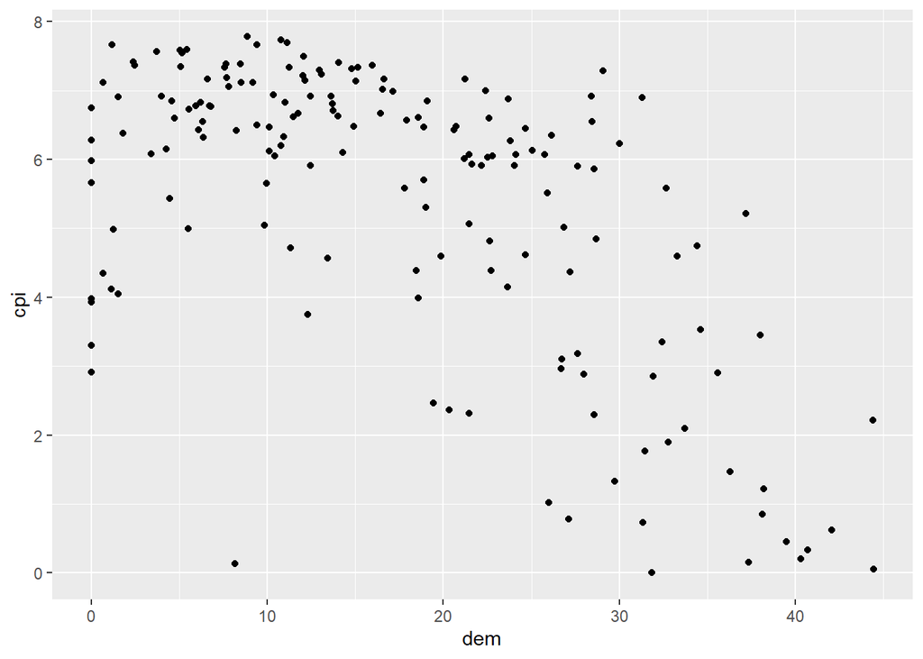

```r
ggplot(lab2, aes(dem, cpi)) + geom_point()
```

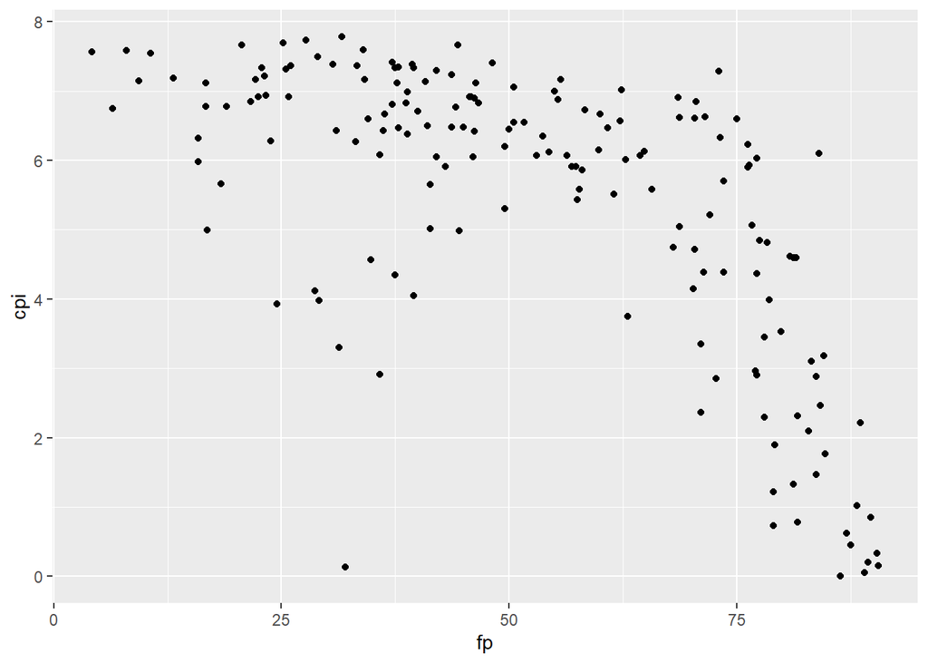

```r
ggplot(lab2, aes(fp, cpi)) + geom_point()
```

На графиках видна нелинейность связи, а именно визуально можно заметить квадратичную зависимость. Несмотря на это мы предложили спецификацию модели, предполагая линейность связи ключевых предикторов и зависимой переменной. Помним, что неверно выбранная функциональная форма взаимосвязи – один из источников гетероскедастичности.

## 3. Гетероскедастичность: визуальные диагностики

Для начала используем визуальные диагностики для определения, есть ли гетероскедастичность в нашей модели (при этом мы уже обсуждали на занятии, какие у нас есть содержательные основания полагать, что гетероскедастичности нам в данном случае не избежать). Построим графики, по оси OX – один из предикторов, по оси OY - остатки в квадрате.

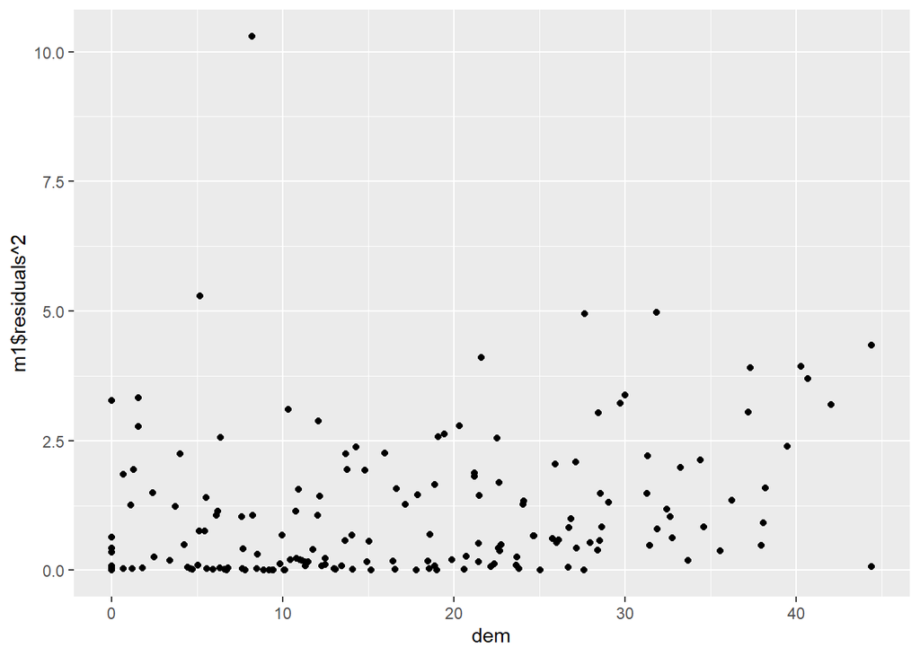

```r
ggplot(lab2, aes(dem, m1$residuals^2)) + geom_point()
```

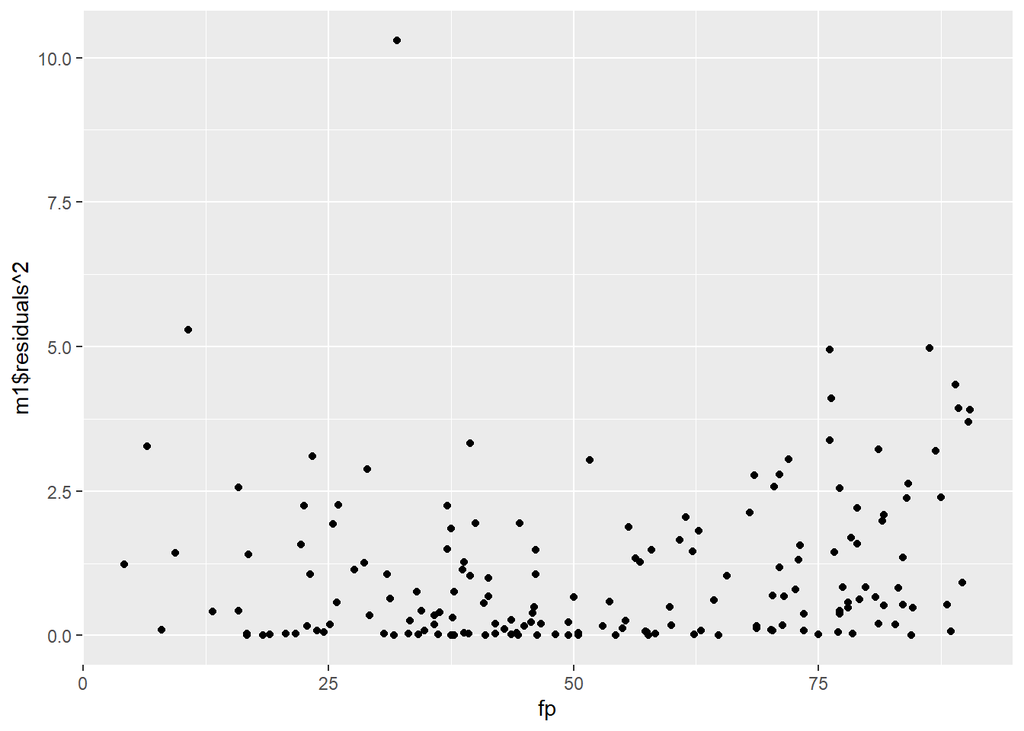

```r
ggplot(lab2, aes(fp, m1$residuals^2)) + geom_point()
```

Конечно, так можно последовательно построить график для каждого предиктора. Можно воспользоваться и более экономным способом: вместо отдельных предикторов по оси OX расположить предсказанные значения зависимой переменной ($\hat{y}$). Для того, чтобы посчитать предсказанные значения отклика, воспользуемся `m1$fitted.values`.

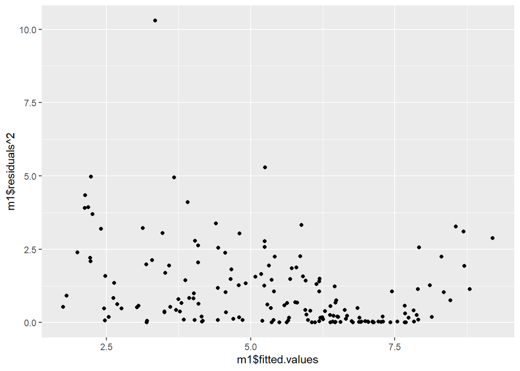

```r
ggplot(lab2, aes(m1$fitted.values, m1$residuals^2)) + geom_point()
```

## 4. Гетероскедастичность: формальные тесты

Тест Уайта – один из тестов для диагностики гетероскедастичности.

1. Сформулируем $H_0: Var(e | X) = const$. В соответствии с нулевой гипотезы предполагаем гомоскедастичность – постоянную условную дисперсию ошибок. Альтернатива: $H_1: Var(e | X) \neq const$
2. Сохраним остатки исходной модели (m1)
3. Оценим вспомогательную модель регрессии остатков в квадрате на исходные предикторы модели m1, эти же предикторы, но в квадрате, и попарные произведения этих предикторов. Сохраним $R^2$ вспомогательной регрессионной модели
4. Статистика критерия рассчитывается как $nR^2$, где $n$ – количество наблюдений, $R^2$ – коэффициент детерминации вспомогательной модели. При верной нулевой гипотезе статистика имеет распределение $\chi^2_{k}$, где $k$ – количество предикторов в вспомогательной регрессионной модели.

Реализуем данный тест в R. По умолчанию модель оценивается без переменных взаимодействия, поэтому дополнительно пропишем `interactions = T`. Обратите внимание на то, что критическая область у нас располагается только с правой стороны, так как если $R^2$ низкий и статистика ближе к нулю, то это напротив будет свидетельствовать в большей степени в пользу нулевой гипотезы (гомоскедастичность, распределение остатков не зависит от предикторов), а не альтернативы.

```r
white(m1, interactions = T)
```

| statistic | p.value | parameter | method | alternative |
| --- | --- | --- | --- | --- |
| 52.57464 | 9.383811e-05 | 20 | White's Test | greater |

Значение p-value мало, поэтому нулевую гипотезу отвергаем, что свидетельствует о гетероскедастичности.

Спецификацию вспомогательной регрессионной модели можно адаптировать. Одним из частных вариантов теста Уайта является тест Бреуша–Пагана. Процедура проверки нулевой гипотезы о гомоскедастичности аналогична, однако только исходные предикторы включаются в спецификацию вспомогательной модели.

```r
bptest(m1)
```

```
##
##  studentized Breusch-Pagan test
##
## data:  m1
## BP = 23.112, df = 5, p-value = 0.0003213
```

Кроме того, спецификацию вспомогательной модели можно самостоятельно адаптировать и включить только предикторы, которые представляются важными для объяснения специфики распределения остатков. К примеру, давайте включим исходные предикторы модели m1 и ключевые предикторы в квадрате (показатели демократии и свободы прессы), как ниже.

```r
bptest(m1, varformula = ~ dem + fp + I(dem^2) + I(fp^2) + loggdppc + stab + britcol, data = lab2)
```

```
##
##  studentized Breusch-Pagan test
##
## data:  m1
## BP = 27.047, df = 7, p-value = 0.0003268
```

Давайте рассмотрим еще один тест для диагностики определенного вида гетероскедастичности – тест Голдфелда–Квандта. Нередки такие случаи гетероскедастичности, когда дисперсия остатков увеличивается с ростом значений предиктора, или наоборот, уменьшается с ростом значений предиктора. Именно для диагностики таких случаев и существует этот тест. Надо отметить, что этот тест параметрический: основывается на допущении о нормальности распределения ошибок регрессионной модели.

1. Первое, что нужно сделать – это упорядочить наблюдения по значениям предиктора, от которых, как мы предполагаем, пропорционально зависит вариация остатков.
2. Для контрастности сравнения выбрасываем середину из этой упорядоченной на первом шаге выборки (как правило, порядка 20-30% наблюдений).
3. В итоге у нас остались две подвыборки ($data_1$ размера $n_1$ и $data_2$ размера $n_2$). Оцениваем исходную регрессионную модель отдельно на первой и второй подвыборках и сохраняем сумму квадратов остатков ($RSS_1$ и $RSS_2$).
4. Статистика критерия строится на основе отношения полученных RSS: $\dfrac{RSS_1/(n_1 - k - 1)}{RSS_2/(n_2 - k - 1)}$. Эта статистика при верной нулевой гипотезе имеет F-распределение с $df1 = n_1 - k - 1$ и $df2 = n_2 - k - 1$.

Для иллюстрации давайте проверим, зависит ли вариация ошибок пропорционально от значений объясняющей переменной – политической стабильности. `fraction = 0.2` – означает, что мы выбрасываем 20% наблюдений из исходной выборки (см. шаг 2 выше). Сделайте вывод на основе полученных результатов.

```r
gqtest(m1, order.by = ~stab, data = lab2, fraction = 0.2, alternative = "two.sided")
```

```
##
##  Goldfeld-Quandt test
##
## data:  m1
## GQ = 2.9936, df1 = 62, df2 = 62, p-value = 2.682e-05
## alternative hypothesis: variance changes from segment 1 to 2
```

## 5. Скорректированные стандартные ошибки

Мы уже обсуждали, что в условиях гетероскедастичности мы получаем неверные стандартные ошибки, что в итоге может привести к некорректным выводам по итогам проверки гипотезы о незначимости коэффициентов в регрессионной модели. В исходной ковариационной матрице ошибок при нашем допущении о гомоскедастичности по главной диагонали постоянное значение $\sigma^2 = RSS/(n-k-1)$. Однако как мы уже выяснили, вариация ошибок нашей модели непостоянна. Поэтому используем скорректированные стандартные ошибки, состоятельные в условиях гетероскедастичности. К примеру, одной из версий таких ошибок является $HC3$, эта версия учитывает при корректировке стандартных ошибок потенциал влияния наблюдения. Как мы видим, стандартные ошибки оценок коэффициентов несколько изменились, однако значимым образом на наши выводы о (не)значимости коэффициентов такая корректировка не повлияла.

```r
coeftest(m1, vcov = vcovHC, type = "HC3")
```

```
##
## t test of coefficients:
##
##               Estimate Std. Error t value  Pr(>|t|)
## (Intercept) 12.2657438  0.6530881 18.7811 < 2.2e-16 ***
## dem         -0.0130296  0.0124803 -1.0440  0.298016
## fp          -0.0181018  0.0069081 -2.6204  0.009608 **
## loggdppc    -0.6742626  0.0780075 -8.6436 4.701e-15 ***
## stab        -0.5484226  0.1228613 -4.4638 1.492e-05 ***
## britcol     -0.4162140  0.2064741 -2.0158  0.045452 *
## ---
## Signif. codes:  0 '***' 0.001 '**' 0.01 '*' 0.05 '.' 0.1 ' ' 1
```